# Lab 3: Exponential Random Graph Modeling

An Introduction in R

Tae-Ung Choi

2017-11-15

# Introduction

In this lab, we will be testing a number of hypotheses about a network’s structure using exponential random graph modeling (ERGM) techniques using the `statnet` package in R. `statnet` provides a comprehensive framework for ERGM-based network modeling, including tools for model estimation, model evaluation, model-based network simulation, and network visualization. This functionality is powered by a central Markov chain Monte Carlo Maximum Likelihood Estimation (MCMCMLE) algorithm.

Mark S. Handcock, David R. Hunter, Carter T. Butts, Steven M. Goodreau, and Martina Morris (2003). `statnet`: Software tools for the Statistical Modeling of Network Data. statnetproject.org; *see also* `?? statnet`. For more information about ERGMs, *see generally* D. Lusher, J. Koskinen, & G. Robins (2012) *Exponential Random Graph Models for Social Networks*.

For a great introduction to MCMC grounded in graph theory, *see* Jeremy Kun, [Markov Chain Monte Carlo Without All the Bullshit.](https://jeremykun.com/2015/04/06/markov-chain-monte-carlo-without-all-the-bullshit/)

`statnet` resources:

● [Developer website](http://csde.washington.edu/statnet/)

● [User guide](http://csde.washington.edu/statnet/users_guide.shtml)

● [Tutorial](http://csde.washington.edu/statnet/Online_Users_Guide/v24i08.pdf)

# Data

We will analyze the communication behaviors within a team of seventeen members who were involved in designing military installations.

- `CRIeq.txt`: each team member’s communication to retrieve information from other team members on the topic of environmental quality (eq). This is a directed, binary relation.
- `CAIeq.txt`: each team member’s communication to allocate information to other team members on the topic of environmental quality (eq). This is a directed, binary relation.
- `EXeq_cons.txt`: each team member’s expertise on the topic of environmental quality (eq) as perceived on average by all team members. This is a continuous attribute.

# Hypotheses

We will test various hypotheses based on the Theory of Transactive Memory.

*See* Monge & Contractor (2003) *Theories of Communication Networks*, 198—203.

*Hypothesis 1*: Individuals are less likely to retrieve information from those who retrieve information from them.

*Hypothesis 2a*: Information retrieval tends to be transitive. That is, if individual *i* retrieves information from individual *k*, and individual *k* retrieves information from individual *j*, then individual *i* is more likely to retrieve information from individual *j*.

*Hypothesis 2b*: Transitivity increases at a sub-linear rate as a function of the number of ties.

*Hypothesis 3a*: Individuals tend to retrieve information from other members with high expertise.

*Hypothesis 3b*: Individuals with low expertise tend to retrieve information from many others.

*Hypothesis 4*: Individuals tend to retrieve information from members to whom they allocate information.

# Part I. Building & Visualizing the Networks (**30 pts**)

The analysis will use three files: the `CRIeq.txt` as the network file, `EXeq_cons.txt` as the attribute file, and `CAIeq.txt` as the co-variate network file. To begin, we must convert the data files into matrices, transform those matrices into networks, and attach the attribute file to our base network.

# Understanding the Base Network

## Analysis

**In your own words, explain what this network respresents and its relationship to our attribute information and the other network.**

# Visualization

Before we conduct further analysis, let’s visualize our base network. Similar to our approach in Lab 2, we will begin by establishing set coordinates for our nodes in order to simplify visual comparisons.

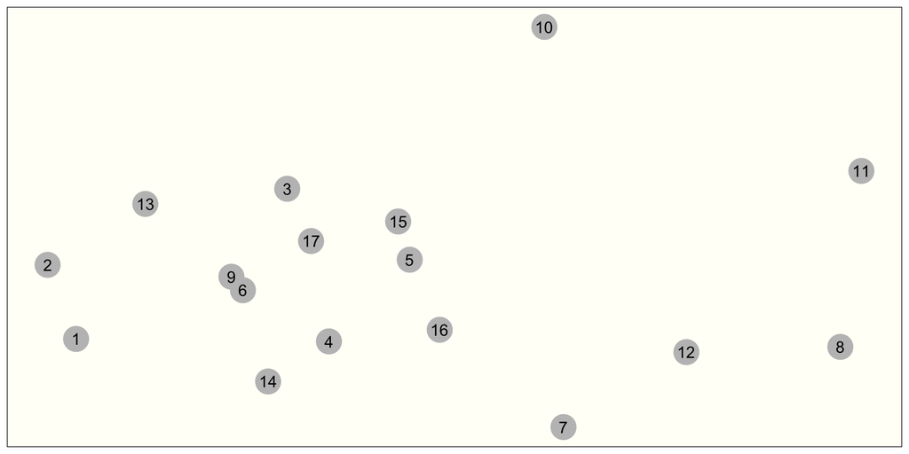

Base Graph Structure

Next we can visualize our base network.

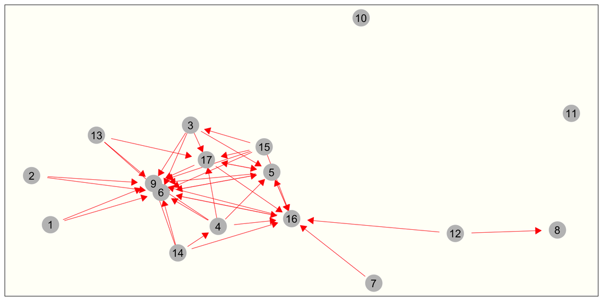

Base Network: Retrieval of Environmental Quality

Next, we will size the nodes by the their expertise value.

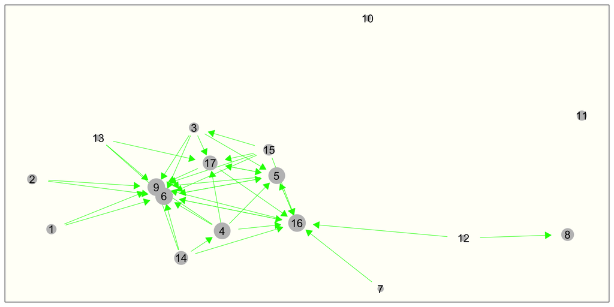

Base Network: Retrieval of Environmental Quality, Nodes Sized by Expertise Score

Let’s compare this visualization to sizing by in-degree centrality.

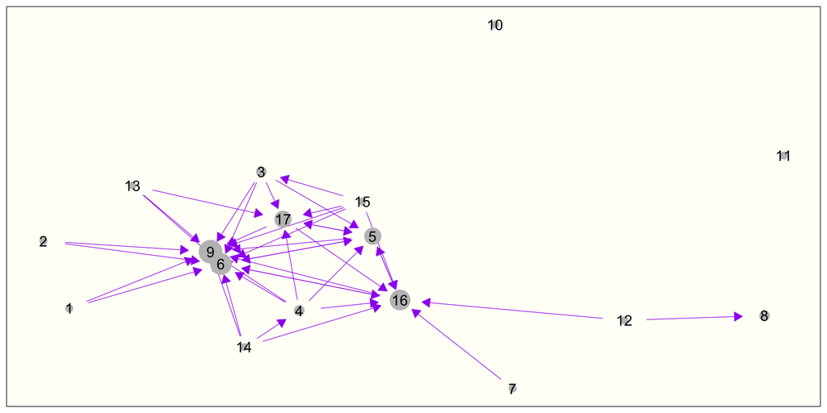

Base Network: Nodes by Indegree Centrality

## Analysis

**Consider hypothesis 3a from Part I. Do these visualizations prove or disprove the hypothesis? In your own words, interpret the graphs and explain how they support or reject the hypothesis.**

Hypothesis 3a says that individuals would retrieve information from others with high expertise. According to the visualization showing the level of expertise, node 16, 6, 9, 4, 5, 17 and 14 seem bigger than other nodes, which indicates that they have higher expertise than others. Judging from node sizes, indegree centralities of the nodes with higher expertise seems also bigger than other nodes with some exceptions such as node 4 and 14. Therefore, in general, I would argue that this graph on average supports the hypothesis 3a.

# Understanding the Covariate Network

Let’s explore the summary statistics of our co-variate network.

```
## Network attributes:
##   vertices = 17
##   directed = TRUE
##   hyper = FALSE
##   loops = FALSE
##   multiple = FALSE
##   bipartite = FALSE
##  total edges = 23
##    missing edges = 0
##    non-missing edges = 23
##  density = 0.08455882
##
## Vertex attributes:
##   vertex.names:
##    character valued attribute
##    17 valid vertex names
##
## No edge attributes
##
## Network edgelist matrix:
##       [,1] [,2]
##  [1,]    7    2
##  [2,]    6    4
##  [3,]    7    4
##  [4,]    9    4
##  [5,]   14    4
##  [6,]    6    5
##  [7,]   17    5
##  [8,]    2    6
##  [9,]   14    6
## [10,]    7    8
## [11,]    2    9
## [12,]    4    9
## [13,]    5    9
## [14,]    6    9
## [15,]   14    9
## [16,]   17    9
## [17,]    4   10
## [18,]    7   11
## [19,]    4   13
## [20,]    5   16
## [21,]    6   16
## [22,]    4   17
## [23,]    5   17
```

## Analysis

**In your own words, explain what this network respresents and its relationship to the other network and the attribute information.**

Network CAIeq is composed of 23 edges from i to j, which represent the relationship that i allocates information to j on the topic of environmental quality. For example, the edge from 7 to 2 indicates that node 7 gives some information about environmental quality to node 2.

# Visualization

We will repeat the visualization process for our co-variate network. Observe the location and distribution of edges in the following visualization.

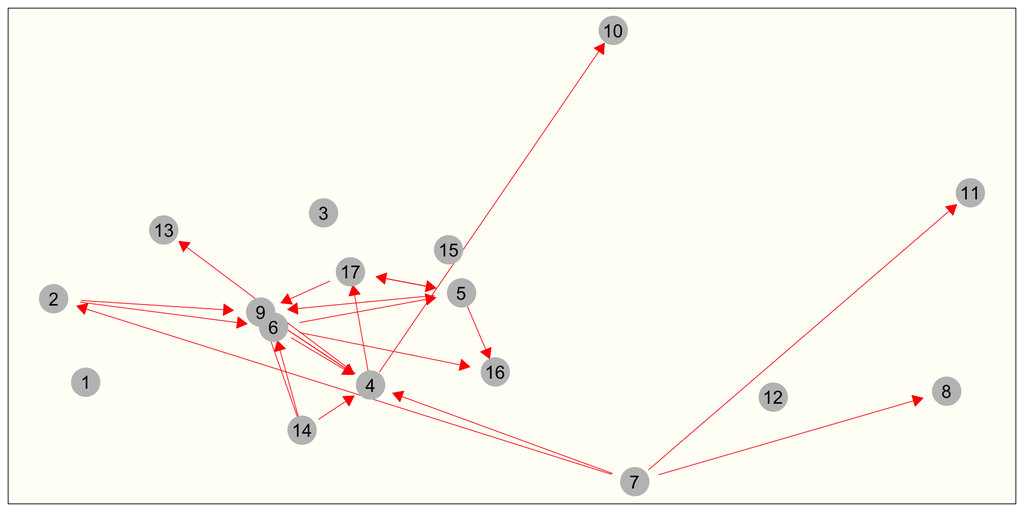

Covariate Network: Allocation of Environmental Quality

Next, we will size the nodes by their expertise scores.

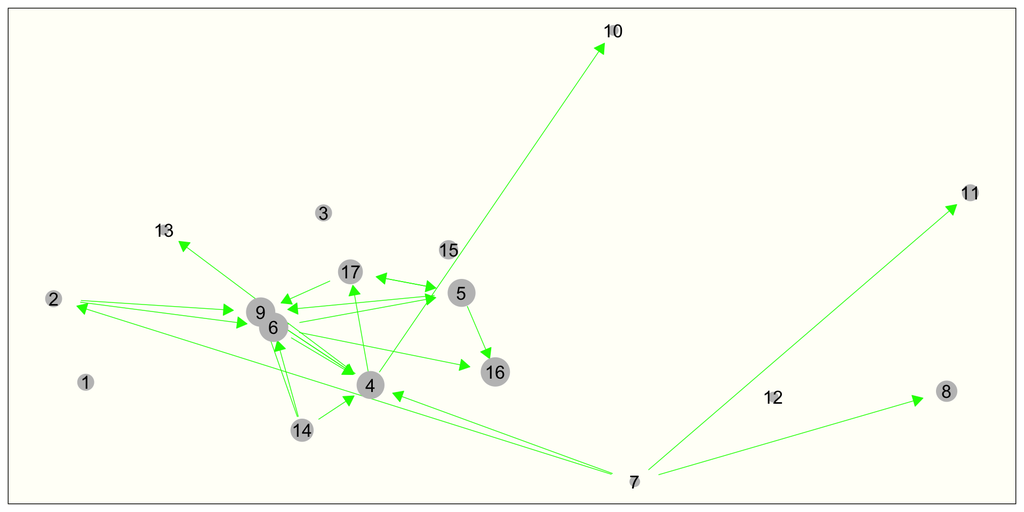

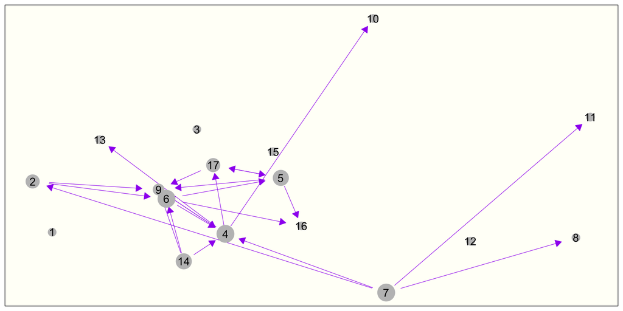

Allocation

## Analysis

**Consider hypothesis 4 from Part I. Do the visualizations of the retrieval and allocation networks sized by expertise support or disprove the hypothesis based on visual inspection? In your own words, interpret the graphs and explain how they support or reject the hypothesis.**

Hypothesis 4 says that individuals retrieve information from others to they allocate information about environmental quality. In order to see this relationship, we need to see whether the allocation tie from i to j, which means node i allocates some information to j, is repeated by the retrieval tie from i to j, which means node i retrieves some information from j. So, I compared each retrieval and allocation edge from i to j and found 14 edges are repeated out of 41 retrieval edges and 23 allocation edges. So, in this network, actors retrieve information from about 60% of all the allocation edges. Therefore, in general, I would conclude that this graph on average support the hypothesis 4.

# Part II: Constructing & Analyzing the ERGM Model (**70 pts**)

Next, we’re going to construct an Exponential Random Graph Model. Note that *model construction* is integral to this process; ERGM is not a single method of analysis, but a type of modelling that requires a theoretical grounding specific to the network and the hypotheses posed by the researcher. While the base ERGM simulation is set to take up to twenty iterations of simulations to fit the model by estimating parameters, it will stop at fewer if the generated networks converge on estimates of our coefficient values or *paramters*. ERGMs are used to predict ties as a function of individual covariates (i.e. attribute data, like “EX” in our example) or network structure.

We will start with a very basic model, looking only at the probability of edge formation, otherwise known as density, to demonstrate how co-efficients can be translated into odds ratios. Keep in mind that the base network is about information retrieval. Our model will primarily allow us to ask what the probability is that an information retrieval relationship will form between two nodes.

The term for tie density (`edges`) is often used similarly to an intercept term in a linear regression or other linear model such as R’s `glm`.

```r
model0 <- ergm(CRIeq ~ edges)
```

```
## Evaluating log-likelihood at the estimate.
```

```r
summary(model0)
```

```
##
## ==========================
## Summary of model fit
## ==========================
##
## Formula:   CRIeq ~ edges
##
## Iterations:  5 out of 20
##
## Monte Carlo MLE Results:
##       Estimate Std. Error MCMC % p-value
## edges  -1.7288     0.1695      0  <1e-04 ***
## ---
## Signif. codes:  0 '***' 0.001 '**' 0.01 '*' 0.05 '.' 0.1 ' ' 1
##
##      Null Deviance: 377.1  on 272  degrees of freedom
##  Residual Deviance: 230.6  on 271  degrees of freedom
##
## AIC: 232.6    BIC: 236.3    (Smaller is better.)
```

What do coefficients mean? Coefficients are the change in the (log-odds) likelihood of a tie for a unit change in a predictor. In our basic model above, our only predictor is information on the number of edges in the network. We can see that the coefficient estimate is negative, suggesting that a tie is more likely not to form than form (i.e. density is less than .5.) To get a better sense of how less likely it is for a tie to form, we can translate our log-odds into a probability.

To translate our estimated coefficient for the `edges` parameter into a probability, we can take the inverse-logit. We are thereby finding the probability that a tie will form in the network, looking only at the number of ties in the base network to build our model. We can see below that this probability is equal to our network density.

```r
plogis(coef(model0)[[1]])
```

```
## [1] 0.1507353
```

```r
network.density(CRIeq)
```

```
## [1] 0.1507353
```

Conceptually, this should be fairly easy to follow: if all we know about a network is the number of ties we have and we’re attempting to predict the probability that an edge will exist solely based on that information, then the probability of an edge existing at any point in the network equals the density of the network as a whole.

As we move on from this toy model, keep in mind that the estimate for our `edges` parameter will change as we add additional predictors or network statistics as additional terms will partially explain tie formation.

# Base Network ERGM

As we build a network, we can evaluate whether individual network statistics or node attributes prove our hypotheses and whether they do so in a way that is significantly different from random chance. Later, we will evaluate whether the model does a good job of explaining our observed network.

```r
model1 <- ergm(CRIeq ~ edges      # Set the base term based on density/edge formation.
               + mutual           # H1
               + transitive       # H2a: Transitive triads ( type 120D, 030T, 120U, or 300) # What if the tie is part of a transitive triad?
               + nodeicov("EX")   # H3a
               + nodeocov("EX")   # H3b
               + edgecov(CAIeq)   # H4
)
```

```
## Starting maximum likelihood estimation via MCMLE:
```

```
## Iteration 1 of at most 20:
```

```
## Optimizing with step length 1.
```

```
## The log-likelihood improved by 0.2307.
```

```
## Step length converged once. Increasing MCMC sample size.
```

```
## Iteration 2 of at most 20:
```

```
## Optimizing with step length 1.
```

```
## The log-likelihood improved by 0.00728.
```

```
## Step length converged twice. Stopping.
```

```
## Evaluating log-likelihood at the estimate. Using 20 bridges: 1 2 3 4 5 6 7 8 9 10 11 12 13 14 15 16 17 18 19 20 .
## This model was fit using MCMC.  To examine model diagnostics and check for degeneracy, use the mcmc.diagnostics() function.
```

```r
summary(model1)
```

```
##
## ==========================
## Summary of model fit
## ==========================
##
## Formula:   CRIeq ~ edges + mutual + transitive + nodeicov("EX") + nodeocov("EX") +
##     edgecov(CAIeq)
##
## Iterations:  2 out of 20
##
## Monte Carlo MLE Results:
##               Estimate Std. Error MCMC % p-value
## edges          -6.9744     1.1490      0 < 1e-04 ***
## mutual         -1.4515     0.9915      0 0.14436
## transitive      0.2817     0.1200      0 0.01969 *
## nodeicov.EX     9.5449     2.0638      0 < 1e-04 ***
## nodeocov.EX     1.2598     1.5984      0 0.43131
## edgecov.CAIeq   2.0994     0.6816      0 0.00229 **
## ---
## Signif. codes:  0 '***' 0.001 '**' 0.01 '*' 0.05 '.' 0.1 ' ' 1
##
##      Null Deviance: 377.1  on 272  degrees of freedom
##  Residual Deviance: 123.8  on 266  degrees of freedom
##
## AIC: 135.8    BIC: 157.4    (Smaller is better.)
```

```r
kable(plogis(coef(model1)))
```

| edges | 0.0009346 |
| --- | --- |
| mutual | 0.1897633 |
| transitive | 0.5699572 |
| nodeicov.EX | 0.9999284 |
| nodeocov.EX | 0.7789891 |
| edgecov.CAIeq | 0.8908474 |

## Analysis

**Take a look at the ERGM equation discussed in the week 5 slides, reproduced below:**

$$\Pr(Y=y)=\exp[\theta'g(y)]/k(\theta)$$

**What term in the equation do the ERGM terms or network statistics correspond to?**

In the equation, g(y) corresponds to network statistics.

**Explain each ERGM term and its relationship to your hypotheses. Test your hypotheses (think about whether the sign of your coefficient suggests a tie is more or less likely) and report whether your results are significant.**

A parameter is significant if its absolute value is more than twice its Standard Error.

*Hypothesis 1*: Individuals are less likely to retrieve information from those who retrieve information from them.

-> In other words, this hypothesis says that if j retrieves information from i, then i is less likely to do so from j, which is in general about reciprocity. According to the coefficient and the standard error of “mutual,” although the direction is consistent with the prediction (i.e., negative coefficient), it is not significant (i.e., |-1.4515| < 0.9915*2).

*Hypothesis 2a*: Information retrieval tends to be transitive. That is, if individual *i* retrieves information from individual *k*, and individual *k* retrieves information from individual *j*, then individual *i* is more likely to retrieve information from individual *j*.

-> According to the coefficient and the standard error of “transitive,” the direction is consistent with the prediction (i.e., positive coefficient), and it is significant (i.e., |0.2817| > 0.12*2).

*Hypothesis 3a*: Individuals tend to retrieve information from other members with high expertise.

-> According to the coefficient and the standard error of “nodeicov.EX,” the direction is consistent with the prediction (i.e., positive coefficient), and it is significant (i.e., |9.5449| > 2.0638*2).

*Hypothesis 3b*: Individuals with low expertise tend to retrieve information from many others.

*Hypothesis 4*: Individuals tend to retrieve information from members to whom they allocate information.

-> According to the coefficient and the standard error of “edgecov.CAIeq,” the direction is consistent with the prediction (i.e., positive coefficient), and it is significant (i.e., |2.0994| > 0.6816*2).

# ERGM Model 2

Now we will change our model slightly.

```r
model2 <- ergm(CRIeq ~ edges
               + mutual                           # H1
               + dgwesp(0.5, fixed=T, type="OTP") # H2b: OTP "transitive shared partner" ordered pair (i,j) iff i->k->j.
               + nodeicov("EX")                   # H3a
               + nodeocov("EX")                   # H3b
               + edgecov(CAIeq)                   # H4
)
```

```
## Starting maximum likelihood estimation via MCMLE:
```

```
## Iteration 1 of at most 20:
```

```
## Optimizing with step length 1.
```

```
## The log-likelihood improved by 0.1652.
```

```
## Step length converged once. Increasing MCMC sample size.
```

```
## Iteration 2 of at most 20:
```

```
## Optimizing with step length 1.
```

```
## The log-likelihood improved by 0.002943.
```

```
## Step length converged twice. Stopping.
```

```
## Evaluating log-likelihood at the estimate. Using 20 bridges: 1 2 3 4 5 6 7 8 9 10 11 12 13 14 15 16 17 18 19 20 .
## This model was fit using MCMC.  To examine model diagnostics and check for degeneracy, use the mcmc.diagnostics() function.
```

```r
summary(model2)
```

```
##
## ==========================
## Summary of model fit
## ==========================
##
## Formula:   CRIeq ~ edges + mutual + dgwesp(0.5, fixed = T, type = "OTP") +
##     nodeicov("EX") + nodeocov("EX") + edgecov(CAIeq)
##
## Iterations:  2 out of 20
##
## Monte Carlo MLE Results:
##                     Estimate Std. Error MCMC %  p-value
## edges                -6.8740     1.2136      0  < 1e-04 ***
## mutual               -1.5142     1.0369      0 0.145398
## gwesp.OTP.fixed.0.5   0.6104     0.3613      0 0.092309 .
## nodeicov.EX           8.9890     2.3300      0 0.000144 ***
## nodeocov.EX           1.3097     1.7263      0 0.448719
## edgecov.CAIeq         2.1134     0.6710      0 0.001821 **
## ---
## Signif. codes:  0 '***' 0.001 '**' 0.01 '*' 0.05 '.' 0.1 ' ' 1
##
##      Null Deviance: 377.1  on 272  degrees of freedom
##  Residual Deviance: 124.3  on 266  degrees of freedom
##
## AIC: 136.3    BIC: 157.9    (Smaller is better.)
```

```r
kable(plogis(coef(model2)))
```

| edges | 0.0010333 |
| --- | --- |
| mutual | 0.1803157 |
| gwesp.OTP.fixed.0.5 | 0.6480383 |
| nodeicov.EX | 0.9998752 |
| nodeocov.EX | 0.7874616 |
| edgecov.CAIeq | 0.8922022 |

## Analysis

**Evaluate the remaining hypothesis with your model.**

*Hypothesis 2b*: Transitivity increases at a sub-linear rate as a function of the number of ties.

-> According to the coefficient and the standard error of “gwesp.OTP.fixed.0.5,” the direction is consistent with the prediction (i.e., positive coefficient), but it is not significant (i.e., |0.6104| < 0.36*2).

# Model Diagnostics

Next, judge convergence of the MCMC processes of the first model, using the `mcmc.diagnostics()` function. The function will plot the change of model statistics during the last iteration of the MCMC estimation procedure. For each model statistic, the left hand side plot gives the change of the statistic with iterations, and the right hand side plot is a histogram of the statistic values. Both are normalized, so the observed data locate at 0.

Note that although the edge graphs appear to be periodic, the dips between whole numbers are due to the fact that edges are always whole numbers.

```r
mcmc.diagnostics(model1)      # Performs the markov chain monte carlo diagnostics
```

```
## Sample statistics summary:
##
## Iterations = 16384:4209664
## Thinning interval = 1024
## Number of chains = 1
## Sample size per chain = 4096
##
## 1. Empirical mean and standard deviation for each variable,
##    plus standard error of the mean:
##
##                  Mean     SD Naive SE Time-series SE
## edges         0.63086  7.375  0.11523        0.17067
## mutual        0.22803  2.473  0.03863        0.05567
## transitive    3.00269 31.115  0.48617        0.71710
## nodeicov.EX   0.32909  3.927  0.06136        0.09246
## nodeocov.EX   0.19260  2.483  0.03880        0.05832
## edgecov.CAIeq 0.04272  1.784  0.02787        0.03580
##
## 2. Quantiles for each variable:
##
##                  2.5%     25%        50%    75%  97.5%
## edges         -12.000  -4.000  0.000e+00  5.000 17.000
## mutual         -3.000  -2.000  0.000e+00  2.000  6.000
## transitive    -40.000 -19.000 -4.000e+00 19.000 82.000
## nodeicov.EX    -6.706  -2.412  5.882e-02  2.824  8.919
## nodeocov.EX    -4.294  -1.529 -2.000e-09  1.824  5.471
## edgecov.CAIeq  -4.000  -1.000  0.000e+00  1.000  3.000
##
##
## Sample statistics cross-correlations:
##                   edges    mutual transitive nodeicov.EX nodeocov.EX
## edges         1.0000000 0.7440785  0.9183834   0.9909533   0.9222568
## mutual        0.7440785 1.0000000  0.8654203   0.7483071   0.8720016
## transitive    0.9183834 0.8654203  1.0000000   0.9245335   0.9371334
## nodeicov.EX   0.9909533 0.7483071  0.9245335   1.0000000   0.9110763
## nodeocov.EX   0.9222568 0.8720016  0.9371334   0.9110763   1.0000000
## edgecov.CAIeq 0.5273759 0.4952026  0.5245660   0.5121310   0.5631972
##               edgecov.CAIeq
## edges             0.5273759
## mutual            0.4952026
```

[output cut: 24 more lines]

```
##
## Fraction in 1st window = 0.1
## Fraction in 2nd window = 0.5
##
##         edges        mutual    transitive   nodeicov.EX   nodeocov.EX
##        0.7790       -0.1910        0.5870        0.6246        0.7619
## edgecov.CAIeq
##       -0.3076
##
## Individual P-values (lower = worse):
##         edges        mutual    transitive   nodeicov.EX   nodeocov.EX
##     0.4360008     0.8485307     0.5572247     0.5322518     0.4461489
## edgecov.CAIeq
##     0.7584113
## Joint P-value (lower = worse):  0.04277244 .
```

```
## Package latticeExtra is not installed. Falling back on coda's default MCMC diagnostic plots.
```

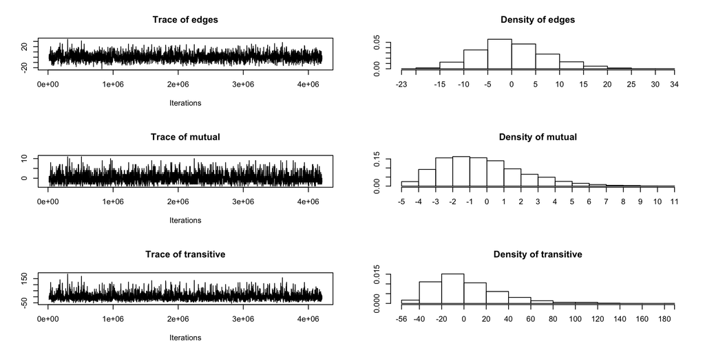

MCMC Diagnostics, Model 1.

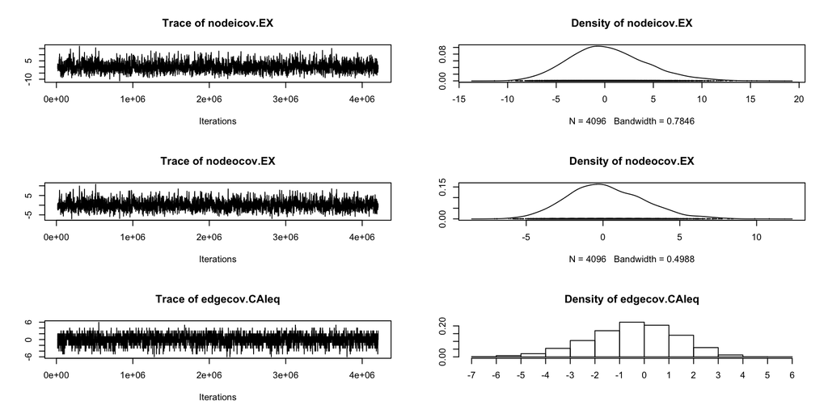

MCMC Diagnostics, Model 1.

```
##
## MCMC diagnostics shown here are from the last round of simulation, prior to computation of final parameter estimates. Because the final estimates are refinements of those used for this simulation run, these diagnostics may understate model performance. To directly assess the performance of the fi…
```

Repeat the process for the second model.

```r
mcmc.diagnostics(model2)      # Performs the markov chain monte carlo diagnostics
```

```
## Sample statistics summary:
##
## Iterations = 16384:4209664
## Thinning interval = 1024
## Number of chains = 1
## Sample size per chain = 4096
##
## 1. Empirical mean and standard deviation for each variable,
##    plus standard error of the mean:
##
##                          Mean     SD Naive SE Time-series SE
## edges               -0.310791  5.357  0.08371        0.08845
## mutual              -0.005127  1.711  0.02674        0.02896
## gwesp.OTP.fixed.0.5 -0.478587 10.028  0.15669        0.17049
## nodeicov.EX         -0.164206  2.864  0.04474        0.04765
## nodeocov.EX         -0.078800  1.689  0.02639        0.02858
## edgecov.CAIeq       -0.079346  1.684  0.02631        0.02908
##
## 2. Quantiles for each variable:
##
##                        2.5%    25%      50%   75%  97.5%
## edges               -10.000 -4.000  0.00000 3.000 10.000
## mutual               -3.000 -1.000  0.00000 1.000  3.000
## gwesp.OTP.fixed.0.5 -19.321 -7.343 -0.82945 6.107 19.445
## nodeicov.EX          -5.684 -2.118 -0.11765 1.765  5.529
## nodeocov.EX          -3.353 -1.191 -0.05882 1.059  3.176
## edgecov.CAIeq        -4.000 -1.000  0.00000 1.000  3.000
##
##
## Sample statistics cross-correlations:
##                         edges    mutual gwesp.OTP.fixed.0.5 nodeicov.EX
## edges               1.0000000 0.5313516           0.8982144   0.9821594
## mutual              0.5313516 1.0000000           0.7194566   0.5381319
## gwesp.OTP.fixed.0.5 0.8982144 0.7194566           1.0000000   0.9165649
## nodeicov.EX         0.9821594 0.5381319           0.9165649   1.0000000
## nodeocov.EX         0.8614649 0.7380090           0.8902859   0.8316911
## edgecov.CAIeq       0.4102323 0.3498729           0.4224946   0.3871053
##                     nodeocov.EX edgecov.CAIeq
## edges                 0.8614649     0.4102323
## mutual                0.7380090     0.3498729
```

[output cut: 24 more lines]

```
##
## Fraction in 1st window = 0.1
## Fraction in 2nd window = 0.5
##
##               edges              mutual gwesp.OTP.fixed.0.5
##           -0.348152           -0.915231           -0.353861
##         nodeicov.EX         nodeocov.EX       edgecov.CAIeq
##           -0.109243           -0.511664           -0.003743
##
## Individual P-values (lower = worse):
##               edges              mutual gwesp.OTP.fixed.0.5
##           0.7277261           0.3600702           0.7234432
##         nodeicov.EX         nodeocov.EX       edgecov.CAIeq
##           0.9130100           0.6088865           0.9970136
## Joint P-value (lower = worse):  0.8045628 .
```

```
## Package latticeExtra is not installed. Falling back on coda's default MCMC diagnostic plots.
```

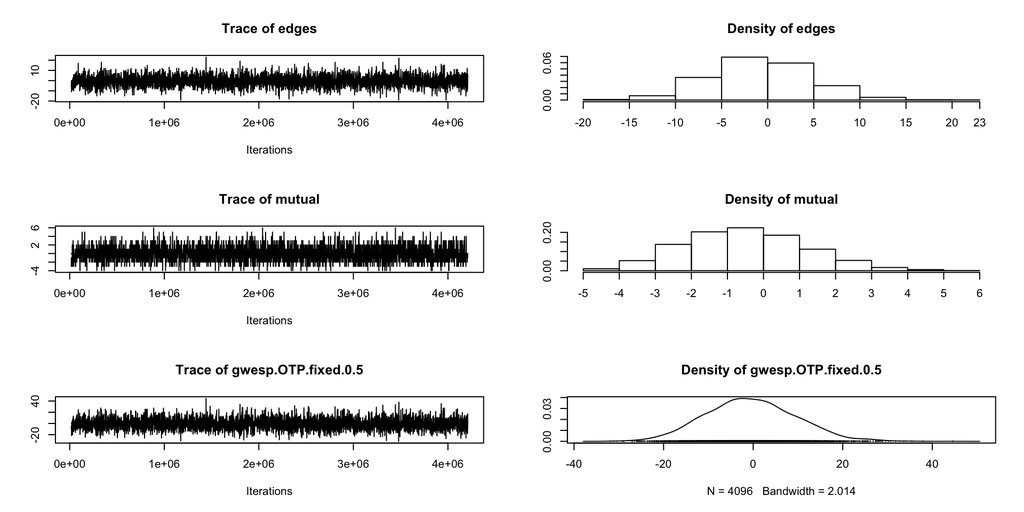

MCMC Diagnostics, Model 2.

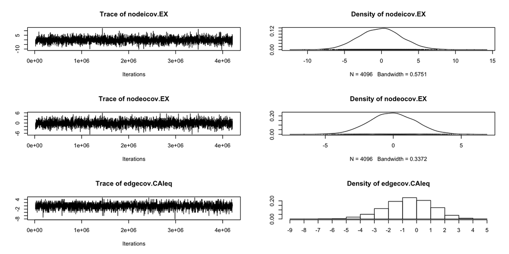

MCMC Diagnostics, Model 2.

```
##
## MCMC diagnostics shown here are from the last round of simulation, prior to computation of final parameter estimates. Because the final estimates are refinements of those used for this simulation run, these diagnostics may understate model performance. To directly assess the performance of the fi…
```

## Analysis

**Has the MCMC process converged to a desired state for each ERGM term? Explain how you interpret the plots.**

D. Lusher et al, *ERGM*, 12.3 (“[T]he inferential goal is to center the distribution of statistics over those of the observed network, thus fitting a model that we say gives maximal support to the data.”)

I would say the MCMC process converged to a desired state for each ERGM term. The plots show what happened to statistics during the last round of simulation. The plots are normalized to the observed data, which is indicated by 0 on the x axis. If a model is converged, then statistics will be centered around their mean, which is the case for this model. The traces of every statistics are not patterned but random. Although, in Model 1, some statistics such as mutual and transitive seem to be a bit steadily away from 0, I would say that those are more or less acceptable.

# Model Evaluation

To evaluate the goodness-of-fit for our model, we need to simulate many variations of the model.

*See* `?? simulate` for more information.

Let’s visually inspect two of our random networks based on our first model.

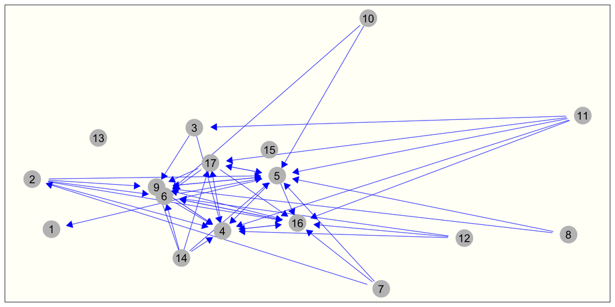

Random Graph Variant, Example 1

```r
ggnet2(sim[[1]], mode = baseLayout, label = TRUE, arrow.size = 8, edge.color="blue", arrow.gap = 0.03) + theme(panel.background = element_rect(fill = "#fffff8")) + guides(color = FALSE, size = FALSE)
```

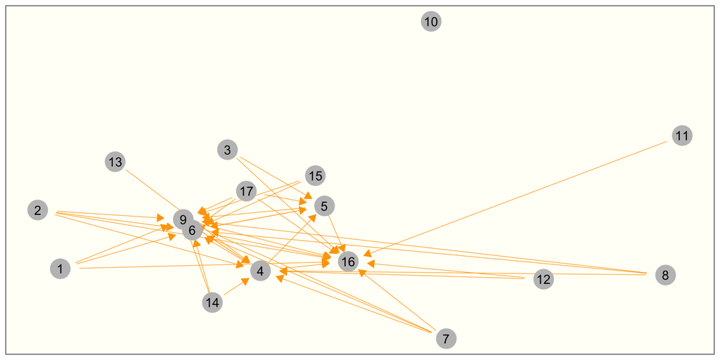

```r
ggnet2(sim[[10]], mode = baseLayout, label = TRUE, arrow.size = 8, edge.color="orange", arrow.gap = 0.03) + theme(panel.background = element_rect(fill = "#fffff8")) + guides(color = FALSE, size = FALSE)
```

Next we’re going to extract the number of triangles from each of the 100 samples, create a histogram of that model, and place a red arrow at the value of the observed network.

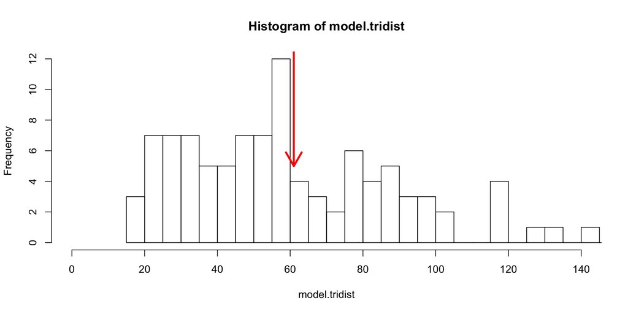

Triangle Distribution

```r
model.tridist <- sapply(1:100, function(x) summary(sim[[x]] ~triangle)) # Extracts the tiangle data from the simulated networks
hist(model.tridist, xlim=c(0,140), breaks = 20)                                     # Plots that triangle distribution as a histogram
CRIeq.tri <- summary(CRIeq ~ triangle)                                  # Saves the CRIeq triangle data from the summary to the CRI.eq variable
arrows(CRIeq.tri,20, CRIeq.tri, 5, col="red", lwd=3)                    # Adds an arrow to the plotted histogram
```

## Analysis

**Is the distribution of triangles in your simulation a good match with the distribution of triangles in your observed network?**

I would say the distribution of triangles in the simulation is a good match with the distribution of triangles in the observed network because the mean of the 100 samples is 61.09, which is almost the same as what I have from the observed network, 61. Also, although not exactly following normal distribution, the histogram shows many simulated observations are centered around the mean.

# Goodness of Fit

Next, we will calculate the Goodness of Fit for several of the parameters in our model. A p-value closer to one is better; this represents the difference between the observed networks and simulations.

```r
gof
```

```
##
## Goodness-of-fit for in-degree
##
##    obs min mean max MC p-value
## 0    9   6 8.93  11       1.00
## 1    3   0 2.02   6       0.66
## 2    0   0 0.70   4       0.92
## 3    0   0 0.50   2       1.00
## 4    0   0 0.52   3       1.00
## 5    2   0 0.60   4       0.16
## 6    0   0 0.75   3       0.88
## 7    0   0 0.74   3       0.86
## 8    1   0 0.74   4       1.00
## 9    1   0 0.64   3       0.88
## 10   0   0 0.44   3       1.00
## 11   1   0 0.21   2       0.40
## 12   0   0 0.14   2       1.00
## 13   0   0 0.07   1       1.00
##
## Goodness-of-fit for out-degree
##
##   obs min mean max MC p-value
## 0   4   0 1.77   6       0.18
## 1   1   1 3.54   9       0.24
## 2   3   0 3.78   8       0.94
## 3   4   0 3.86   8       1.00
## 4   3   0 2.59   7       0.94
## 5   2   0 1.15   4       0.62
## 6   0   0 0.30   2       1.00
## 7   0   0 0.01   1       1.00
##
## Goodness-of-fit for edgewise shared partner
##
##      obs min  mean max MC p-value
## esp0  10   3 11.75  21       0.82
## esp1  13   2 12.02  20       0.90
## esp2  11   2  9.97  20       0.96
## esp3   5   0  4.93  18       0.86
## esp4   2   0  1.69   8       0.86
## esp5   0   0  0.28   4       1.00
## esp6   0   0  0.02   2       1.00
##
## Goodness-of-fit for minimum geodesic distance
##
##     obs min   mean max MC p-value
## 1    41  26  40.66  56       0.98
## 2    19  20  37.96  73       0.00
## 3     4   0  13.37  37       0.30
## 4     0   0   3.52  22       0.62
## 5     0   0   0.92   7       1.00
## 6     0   0   0.09   3       1.00
## 7     0   0   0.01   1       1.00
## Inf 208 106 175.47 220       0.14
```

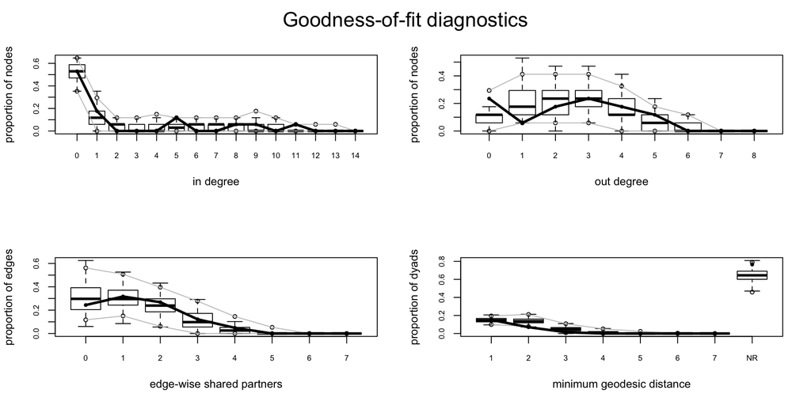

Goodness of Fit

```r
# -------------------------------------------------------------------------------------------------
# Test the goodness of fit of the model
# Compiles statistics for these simulations as well as the observed network, and calculates p-values
# -------------------------------------------------------------------------------------------------

par(mfrow=c(2,2))   # Separate the plot window into a 2 by 2 orientation
plot(gof)           # Plot the goodness of fit
```

## Analysis

**Evaluate the plots and summary statitistics of the Goodness of Fit measures for Model 1. Are the four terms evaluated show a good fit between the simulated networks and thex observed network?**

In general, for configurations in the model, the fit is considered good if │*t*│≤ 0.1. For configurations not included in the model, the fit is considered good if 0.1<│*t*│≤ 1, and not extreme if 1< │*t*│≤ 2. For your plot, the dark black line represents the data for the observed network. The boxplots represent the distribution of corresponding degrees across the simulated networks, and the soft lines are the 95% confidence intervals.

# Submitting the Lab (**5 pts**)

After knitting your file to RPubs, copy the URL and paste it into the comment field of the Lab 2 Assignment on Canvas. Save this .Rmd file and submit it in the file portion of your Canvas assignment. Make sure to review your file and its formatting. **Run spell check (built into RStudio) and proofread your answers before submitting.** If you can’t publish to RPubs, save your HTML file as a PDF and submit that instead.

There are many different ways to do this with different browsers. Google it.